# Gradient Boosting

Cabalar, Salazar, Wang

20 July 2026

## 1. What is Gradient Boosting?

Gradient boosting is an ensemble (supervised) machine learning method that builds a strong predictive model by combining many weak learners, usually shallow decision trees, in a sequential manner.

Unlike a model that is trained once, gradient boosting builds trees one after another, where each new tree is trained to correct the errors (residuals) made by the combination of all previous trees. The final prediction is the sum of the predictions of all the trees, each one scaled down by a learning rate.

### How is this different from Random Forest?

| Aspect | Random Forest | Gradient Boosting |
| --- | --- | --- |
| Tree building | Trees are built independently, in parallel | Trees are built sequentially, each depending on the last |
| Data used | Each tree uses a bootstrap sample of the data | Each tree uses the whole dataset, but fits the residual errors of the previous trees |
| Goal of each tree | Predict the response directly | Predict the *error* left over by earlier trees |
| Combining predictions | Majority vote (classification) or average (regression) | Additive: predictions are summed together, each weighted by a learning rate |
| Overfitting control | Averaging many deep, independent trees reduces variance | Achieved through learning rate, tree depth, and number of trees; more prone to overfitting if not tuned |
| Sensitivity to outliers | Less sensitive | More sensitive, since it keeps fitting residuals |

In short, Random Forest reduces variance by averaging many independent trees built from randomized data, while Gradient Boosting reduces bias by having each new tree specifically target the mistakes of the trees before it.

## 2. Types of Gradient Boosting Implementations

Like Random Forest, gradient boosting can be implemented differently depending on the type of the response variable.

### A. Regression Gradient Boosting

Used when the response variable is continuous. Each new tree is fit to the residuals (actual value minus current prediction) of the previous ensemble. The loss function is typically the squared error, so the residuals used to fit each tree are simply the pseudo-residuals $y_i - F_{m-1}(x_i)$.

### B. Classification Gradient Boosting

Used when the response variable is categorical. Instead of fitting residuals of the raw class labels, the model works on the predicted *log-odds* (for binary outcomes) or class probabilities, and the pseudo-residuals are derived from the gradient of a loss function such as log-loss (deviance). The predicted probabilities are converted back to classes using the logistic (sigmoid) or softmax function.

### C. Popular Software Implementations

Aside from the classic (regression/classification) split above, gradient boosting is also commonly grouped by the specific algorithm/ library used to implement it, since each one adds its own optimizations:

- **GBM (Gradient Boosting Machine)** — the classic, general-purpose implementation described above (e.g., R’s `gbm` package).
- **XGBoost (Extreme Gradient Boosting)** — adds regularization and second-order gradient information for faster, more accurate models.
- **LightGBM** — uses histogram-based, leaf-wise tree growth for speed on large datasets.
- **CatBoost** — designed to natively handle categorical predictors without manual encoding.

## 3. Chosen Implementation: Regression Gradient Boosting

For this activity, **Regression Gradient Boosting** was chosen. The general steps (studied with the help of AI) are:

**STEPS:**

1. Prepare the dataset
2. Specify the response variable
3. Initialize the model with a constant prediction (the mean of Y)
4. Compute pseudo-residuals (actual value minus current prediction)
5. Fit a weak learner (a decision stump) to the pseudo-residuals
6. Find the split that minimizes the Sum of Squared Errors (SSE) of the residuals
7. Update the overall prediction by adding the new tree’s prediction, scaled by a learning rate
8. Repeat steps d–g for a set number of trees (iterations)
9. Track training error across iterations
10. Combine all trees to get the final prediction

$$F_m(x) = F_{m-1}(x) + \nu \cdot
h_m(x)$$

where

- $F_{m-1}(x)$ = prediction from the ensemble so far
- $h_m(x)$ = prediction of the new tree, fit on the residuals
- $\nu$ = learning rate (shrinkage), controls how much each tree contributes

## 4. Manual R Implementation (No Packages)

### Step a. Prepare the dataset

```r
data(iris)

## Predictor variables
X <- iris[, c("Sepal.Width", "Petal.Length", "Petal.Width")]

## Response variable (continuous)
Y <- iris$Sepal.Length

## Number of observations
n <- nrow(iris)
```

### Step b. Specify the response variable

```r
response <- "Sepal.Length"
```

### Step c. Initialize the model

```r
## Start with the simplest possible model: predict the mean for everyone
F0 <- mean(Y)
prediction <- rep(F0, n)

cat("Initial prediction (mean of Y):", F0, "\n")
```

```
## Initial prediction (mean of Y): 5.843333
```

### Steps d–f. Function to fit one decision stump to residuals

```r
## A "stump" is a decision tree with only one split.
## It finds the variable and split point that best
## reduces the Sum of Squared Errors (SSE) of the residuals.

train_stump <- function(X, residuals){

  best_sse <- Inf
  best_variable <- NA
  best_split <- NA
  best_left_pred <- NA
  best_right_pred <- NA

  for(variable in names(X)){
    values <- sort(unique(X[[variable]]))
    if(length(values) < 2)
      next
    splits <- (values[-1] + values[-length(values)]) / 2

    for(split in splits){
      left_idx <- X[[variable]] <= split
      right_idx <- !left_idx

      if(sum(left_idx) == 0 || sum(right_idx) == 0)
        next

      left_pred <- mean(residuals[left_idx])
      right_pred <- mean(residuals[right_idx])

      sse <-
        sum((residuals[left_idx] - left_pred)^2) +
        sum((residuals[right_idx] - right_pred)^2)

      if(sse < best_sse){
        best_sse <- sse
        best_variable <- variable
        best_split <- split
        best_left_pred <- left_pred
        best_right_pred <- right_pred
      }
    }
  }

  list(
    variable = best_variable,
    split = best_split,
    left_pred = best_left_pred,
    right_pred = best_right_pred,
    sse = best_sse
  )
}
```

### Steps d–j. Boosting loop

```r
set.seed(123)

## Number of boosting iterations (trees)
n_trees <- 50

## Learning rate (shrinkage)
learning_rate <- 0.1

## Store each stump and the training error per iteration
stumps <- vector("list", n_trees)
train_mse <- numeric(n_trees)

for(m in 1:n_trees){

  ## Step d. Compute pseudo-residuals
  residuals <- Y - prediction

  ## Step e-f. Fit a stump to the residuals
  stump <- train_stump(X, residuals)
  stumps[[m]] <- stump

  ## Get this stump's prediction for every observation
  left_idx <- X[[stump$variable]] <= stump$split
  stump_pred <- ifelse(left_idx, stump$left_pred, stump$right_pred)

  ## Step g. Update overall prediction (with shrinkage)
  prediction <- prediction + learning_rate * stump_pred

  ## Step i. Track training error
  train_mse[m] <- mean((Y - prediction)^2)

  cat("Tree", m,
      "- Variable:", stump$variable,
      "- Training MSE:", round(train_mse[m], 4), "\n")
}
```

```
## Tree 1 - Variable: Petal.Length - Training MSE: 0.6017
## Tree 2 - Variable: Petal.Length - Training MSE: 0.5364
## Tree 3 - Variable: Petal.Length - Training MSE: 0.4827
## Tree 4 - Variable: Petal.Length - Training MSE: 0.4375
## Tree 5 - Variable: Petal.Length - Training MSE: 0.399
## Tree 6 - Variable: Petal.Length - Training MSE: 0.3665
## Tree 7 - Variable: Petal.Length - Training MSE: 0.3379
## Tree 8 - Variable: Petal.Length - Training MSE: 0.312
## Tree 9 - Variable: Petal.Length - Training MSE: 0.2898
## Tree 10 - Variable: Petal.Length - Training MSE: 0.2707
## Tree 11 - Variable: Petal.Length - Training MSE: 0.2527
## Tree 12 - Variable: Petal.Length - Training MSE: 0.2372
## Tree 13 - Variable: Petal.Length - Training MSE: 0.223
## Tree 14 - Variable: Petal.Length - Training MSE: 0.211
## Tree 15 - Variable: Petal.Length - Training MSE: 0.1998
## Tree 16 - Variable: Petal.Length - Training MSE: 0.1901
## Tree 17 - Variable: Petal.Length - Training MSE: 0.1816
## Tree 18 - Variable: Petal.Length - Training MSE: 0.1736
## Tree 19 - Variable: Petal.Length - Training MSE: 0.1667
## Tree 20 - Variable: Petal.Length - Training MSE: 0.1605
## Tree 21 - Variable: Petal.Width - Training MSE: 0.1549
## Tree 22 - Variable: Petal.Length - Training MSE: 0.1497
## Tree 23 - Variable: Petal.Width - Training MSE: 0.1453
## Tree 24 - Variable: Petal.Length - Training MSE: 0.1412
## Tree 25 - Variable: Petal.Length - Training MSE: 0.1377
## Tree 26 - Variable: Petal.Length - Training MSE: 0.1345
## Tree 27 - Variable: Petal.Length - Training MSE: 0.1315
## Tree 28 - Variable: Petal.Length - Training MSE: 0.129
## Tree 29 - Variable: Petal.Width - Training MSE: 0.1267
## Tree 30 - Variable: Petal.Length - Training MSE: 0.1245
## Tree 31 - Variable: Petal.Length - Training MSE: 0.1226
## Tree 32 - Variable: Petal.Length - Training MSE: 0.1208
## Tree 33 - Variable: Sepal.Width - Training MSE: 0.1193
## Tree 34 - Variable: Petal.Length - Training MSE: 0.1177
## Tree 35 - Variable: Petal.Length - Training MSE: 0.1163
## Tree 36 - Variable: Sepal.Width - Training MSE: 0.115
## Tree 37 - Variable: Petal.Length - Training MSE: 0.1136
## Tree 38 - Variable: Sepal.Width - Training MSE: 0.1125
## Tree 39 - Variable: Petal.Length - Training MSE: 0.1113
## Tree 40 - Variable: Petal.Length - Training MSE: 0.1102
## Tree 41 - Variable: Petal.Length - Training MSE: 0.1092
## Tree 42 - Variable: Sepal.Width - Training MSE: 0.1083
## Tree 43 - Variable: Petal.Length - Training MSE: 0.1074
## Tree 44 - Variable: Sepal.Width - Training MSE: 0.1065
## Tree 45 - Variable: Petal.Length - Training MSE: 0.1056
## Tree 46 - Variable: Sepal.Width - Training MSE: 0.1048
## Tree 47 - Variable: Petal.Length - Training MSE: 0.104
## Tree 48 - Variable: Petal.Length - Training MSE: 0.1033
## Tree 49 - Variable: Sepal.Width - Training MSE: 0.1025
## Tree 50 - Variable: Sepal.Width - Training MSE: 0.1018
```

### Step j. Final prediction

```r
cat("\nFinal predictions (first 6 observations):\n")
```

```
##
## Final predictions (first 6 observations):
```

```r
print(head(prediction))
```

```
## [1] 5.016257 5.016257 5.016257 5.037579 5.016257 5.314940
```

```r
cat("\nActual values (first 6 observations):\n")
```

```
##
## Actual values (first 6 observations):
```

```r
print(head(Y))
```

```
## [1] 5.1 4.9 4.7 4.6 5.0 5.4
```

```r
## Final training MSE
cat("\nFinal Training MSE:", round(train_mse[n_trees], 4), "\n")
```

```
##
## Final Training MSE: 0.1018
```

### Visualize training error across boosting iterations

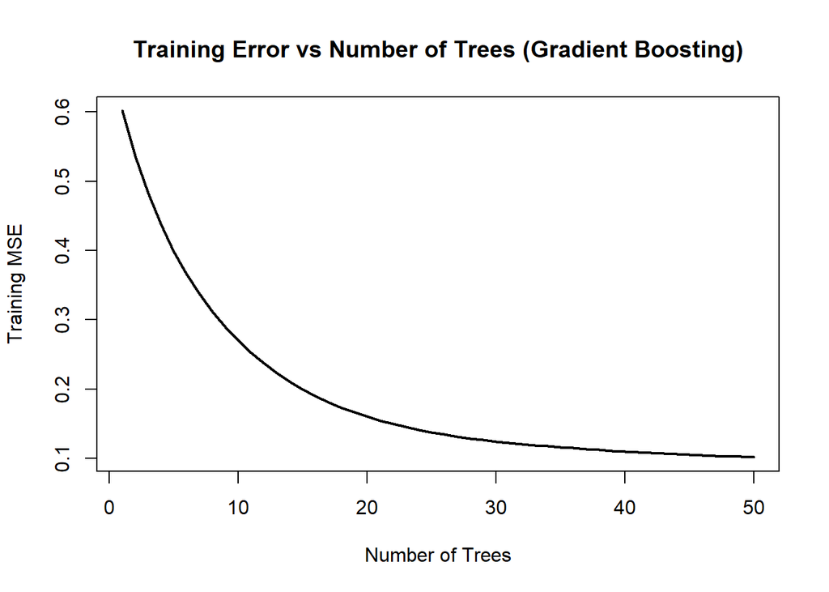

```r
plot(train_mse,
     type = "l",
     col = "black",
     lwd = 2,
     xlab = "Number of Trees",
     ylab = "Training MSE",
     main = "Training Error vs Number of Trees (Gradient Boosting)")
```

### Predict a new observation using all trees

```r
new_flower <- iris[1, ]

## Start from the initial constant prediction
new_prediction <- F0

for(m in 1:n_trees){
  stump <- stumps[[m]]
  if(new_flower[[stump$variable]] <= stump$split){
    step_pred <- stump$left_pred
  } else{
    step_pred <- stump$right_pred
  }
  new_prediction <- new_prediction + learning_rate * step_pred
}

cat("Actual Sepal.Length :", new_flower$Sepal.Length, "\n")
```

```
## Actual Sepal.Length : 5.1
```

```r
cat("Predicted Sepal.Length:", round(new_prediction, 3), "\n")
```

```
## Predicted Sepal.Length: 5.016
```

## 5. Using the “gbm” Package (For Comparison)

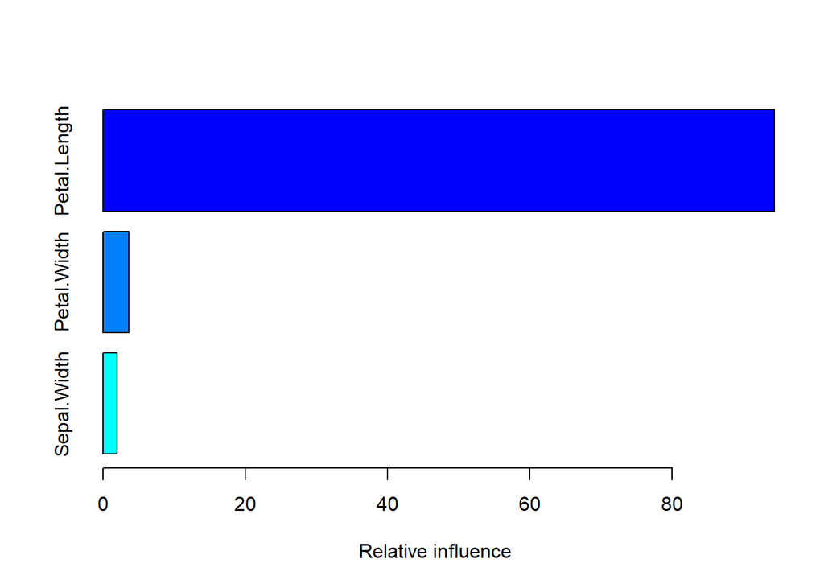

```
##                       var   rel.inf
## Petal.Length Petal.Length 94.401059
## Petal.Width   Petal.Width  3.593198
## Sepal.Width   Sepal.Width  2.005743
```

```r
## Install package (run once)
## install.packages("gbm")

library(gbm)

set.seed(123)

gbm_model <- gbm(
  Sepal.Length ~ Sepal.Width + Petal.Length + Petal.Width,
  data = iris,
  distribution = "gaussian",   ## regression
  n.trees = 50,
  shrinkage = 0.1,
  interaction.depth = 1        ## depth 1 = decision stump
)

## View model summary and variable importance
summary(gbm_model)
```

```r
## Predictions using all 50 trees
gbm_predictions <- predict(gbm_model, n.trees = 50)

## Compare training MSE with the manual implementation
gbm_mse <- mean((iris$Sepal.Length - gbm_predictions)^2)
cat("gbm package Training MSE:", round(gbm_mse, 4), "\n")
```

```
## gbm package Training MSE: 0.1149
```

```r
cat("Manual implementation Training MSE:", round(train_mse[n_trees], 4), "\n")
```

```
## Manual implementation Training MSE: 0.1018
```